# Extended information on ggcpb

This vignette extends the introduction. It shows more options for the figure types, such as colours, columns, boxplots and maps. The parameters next to a figure work in Excel, as explained in the introduction and in the import vignette. The same figures can be made in R. The last sections show what is possible in R only.

# 1 Column charts

The introduction shows columns with a second axis and horizontal bars. This section shows the position of the columns and the limits of the value axis.

## 1.1 Stacked columns

With `position = stack` the columns are placed on top of each other. Dodged is the default position. The legend follows the order of the series. Set `reverse_legend` to `TRUE` if you want to reverse the legend order.

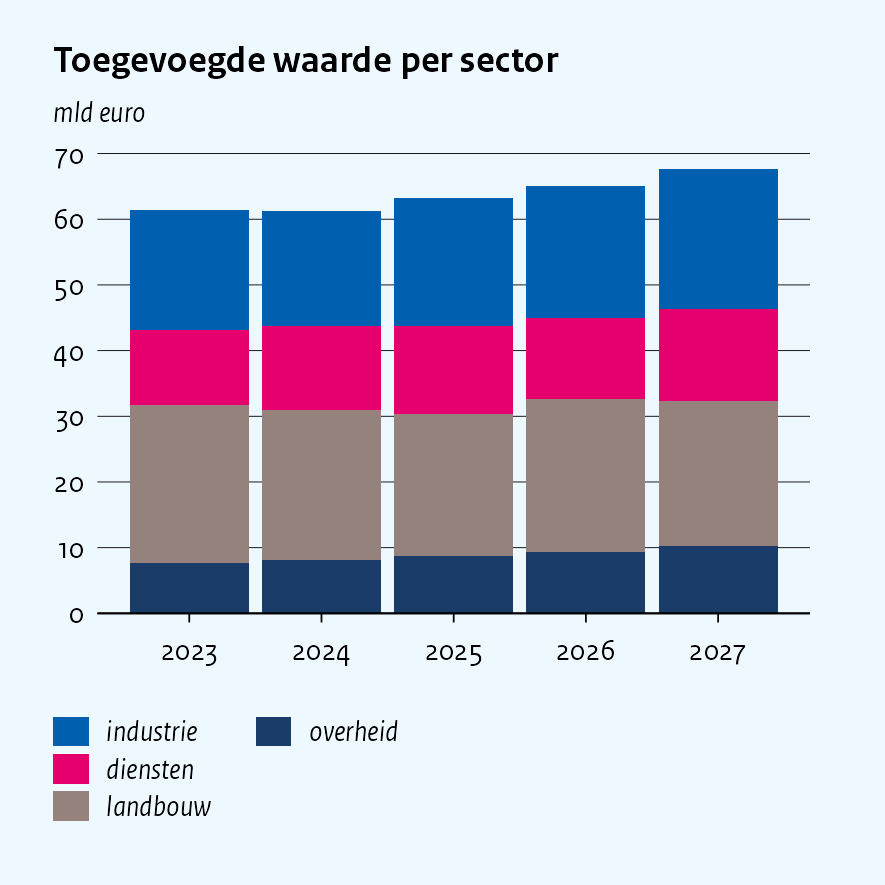

#### Relevant parameters

| plot_type | col |
| --- | --- |
| title | Toegevoegde waarde per sector |
| x | jaar |
| y | waarde |
| fill | sector |
| position | stack |
| ylab | mld euro |

**How to reproduce this figure:** copy `params.csv`, `generate_plot.bat` and the folder `data` with `col-stacked.csv` to a personal folder. Fill in the parameters above in `params.csv` and start the script. In R you can call `cpb_col()` instead. Follow the example code in section 6.6 to create the plot in R. Alternatively, the csv file can be read with `read.csv()` and used as input to `cpb_col()`.

The example data and `params.csv` are in the folder `examples` of the installed package. Run the script again after every change to update the figures. The import vignette explains all settings per figure type.

## 1.2 Dodged columns

Dodged is the default position, so the columns stand next to each other. The legend then follows the order of the series.

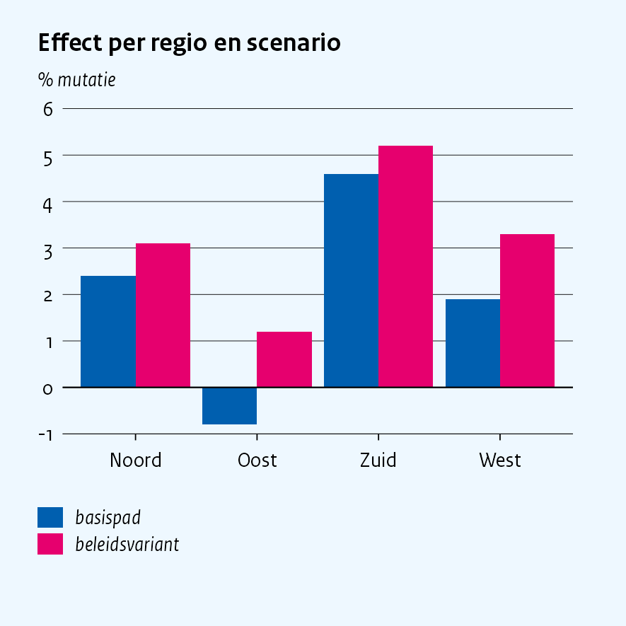

#### Relevant parameters

| plot_type | col |
| --- | --- |
| title | Effect per regio en scenario |
| x | regio |
| y | effect |
| fill | scenario |
| ylab | % mutatie |

**How to reproduce this figure:** copy `params.csv`, `generate_plot.bat` and the folder `data` with `col-dodged.csv` to a personal folder. Fill in the parameters above in `params.csv` and start the script. In R you can call `cpb_col()` instead. Follow the example code in section 6.7 to create the plot in R. Alternatively, the csv file can be read with `read.csv()` and used as input to `cpb_col()`.

## 1.3 Limits and percentages

The value axis follows the data. It starts and ends where the data does. Use `value_limits` to set the limits yourself, such as 0 and 100 for a share. `pct_axis` writes the values as percentages. The axis widens when the data runs past the limits. With `value_crop` set to `TRUE` the data outside the limits is cut off, with a warning.

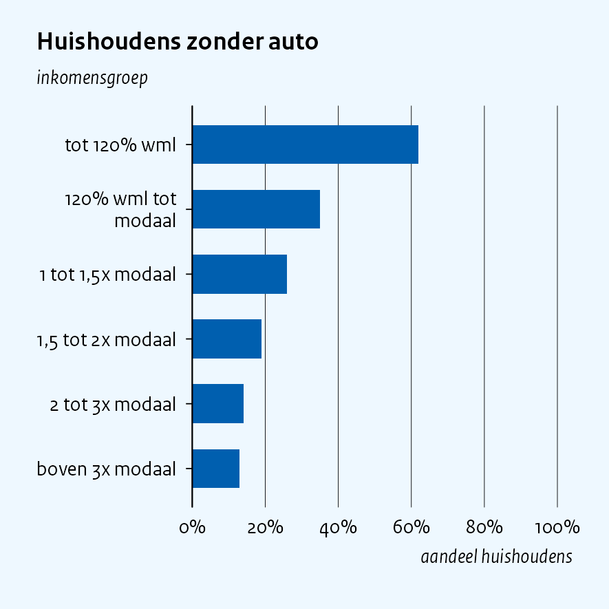

#### Relevant parameters

| plot_type | col |
| --- | --- |
| title | Huishoudens zonder auto |
| x | inkomensgroep |
| y | share |
| orientation | horizontal |
| pct_axis | TRUE |
| value_limits | 0;100 |
| width | 0.6 |
| ylab | inkomensgroep |
| xlab | aandeel huishoudens |

**How to reproduce this figure:** copy `params.csv`, `generate_plot.bat` and the folder `data` with `col-limits.csv` to a personal folder. Fill in the parameters above in `params.csv` and start the script. In R you can call `cpb_col()` instead. Follow the example code in section 6.8 to create the plot in R. Alternatively, the csv file can be read with `read.csv()` and used as input to `cpb_col()`.

# 2 Boxplot styles

The introduction shows the default style of `cpb_box()` and the extended boxplot. `box_style` sets how a box is drawn. This section shows the other styles. All styles need the quantiles in columns, so aggregate the data first.

## 2.1 James style

`james` is the box of the old James plotter. It has no border, and a black median that sticks out. The value of the median is printed above it.

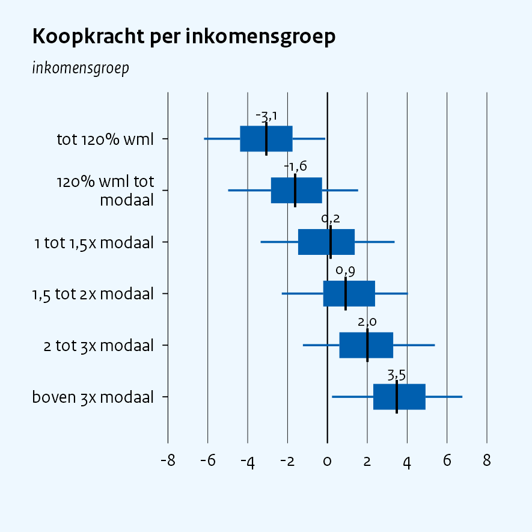

#### Relevant parameters

| plot_type | box |
| --- | --- |
| title | Koopkracht per inkomensgroep |
| x | groep |
| p5 | p5 |
| p25 | p25 |
| p50 | p50 |
| p75 | p75 |
| p95 | p95 |
| box_style | james |
| orientation | horizontal |
| subtitle | inkomensgroep |
| ylab | % koopkrachtmutatie |

**How to reproduce this figure:** copy `params.csv`, `generate_plot.bat` and the folder `data` with `box-james.csv` to a personal folder. Fill in the parameters above in `params.csv` and start the script. In R you can call `cpb_box()` instead. Follow the example code in section 6.9 to create the plot in R. Alternatively, the csv file can be read with `read.csv()` and used as input to `cpb_box()`.

## 2.2 Modern style

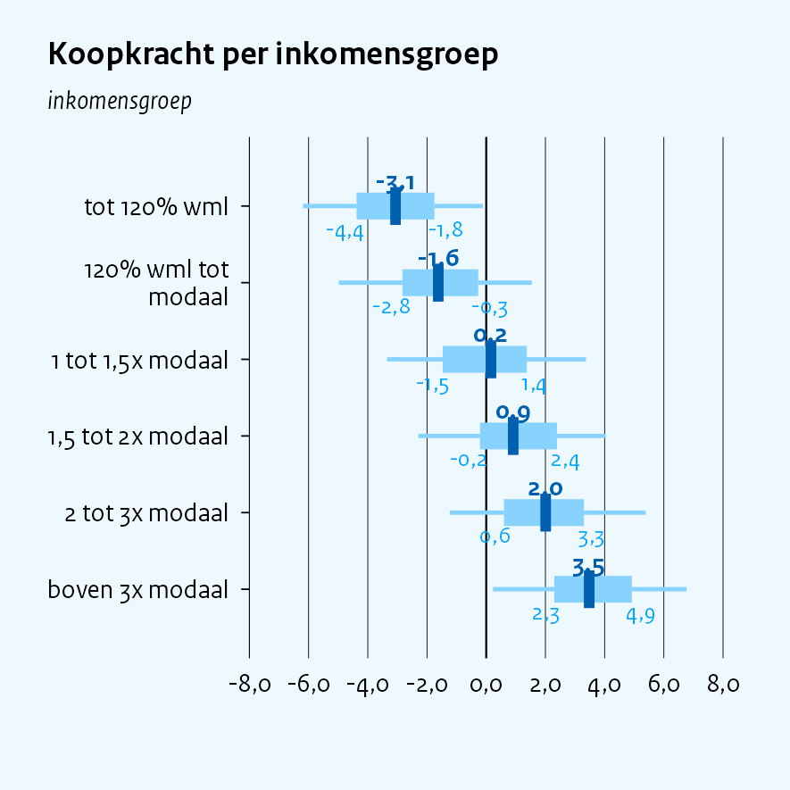

#### Relevant parameters

| plot_type | box |
| --- | --- |
| title | Koopkracht per inkomensgroep |
| x | groep |
| p5 | p5 |
| p25 | p25 |
| p50 | p50 |
| p75 | p75 |
| p95 | p95 |
| box_style | modern |
| orientation | horizontal |
| width | 0.35 |
| value_accuracy | 0.1 |
| subtitle | inkomensgroep |
| ylab | % koopkrachtmutatie |

**How to reproduce this figure:** copy `params.csv`, `generate_plot.bat` and the folder `data` with `box-modern.csv` to a personal folder. Fill in the parameters above in `params.csv` and start the script. In R you can call `cpb_box()` instead. Follow the example code in section 6.10 to create the plot in R. Alternatively, the csv file can be read with `read.csv()` and used as input to `cpb_box()`.

## 2.3 Grouped boxes

`group` places the categories under bold group names. All boxes share one value axis. A group with one category of the same name, such as Totaal, takes one row. `colour_index` takes one palette position per group, so the boxes of a group share a colour. `value_axis = top` puts the value axis along the top of the figure. This works for horizontal boxes. A grouped figure is taller, so this one is saved with `height = 11.4`.

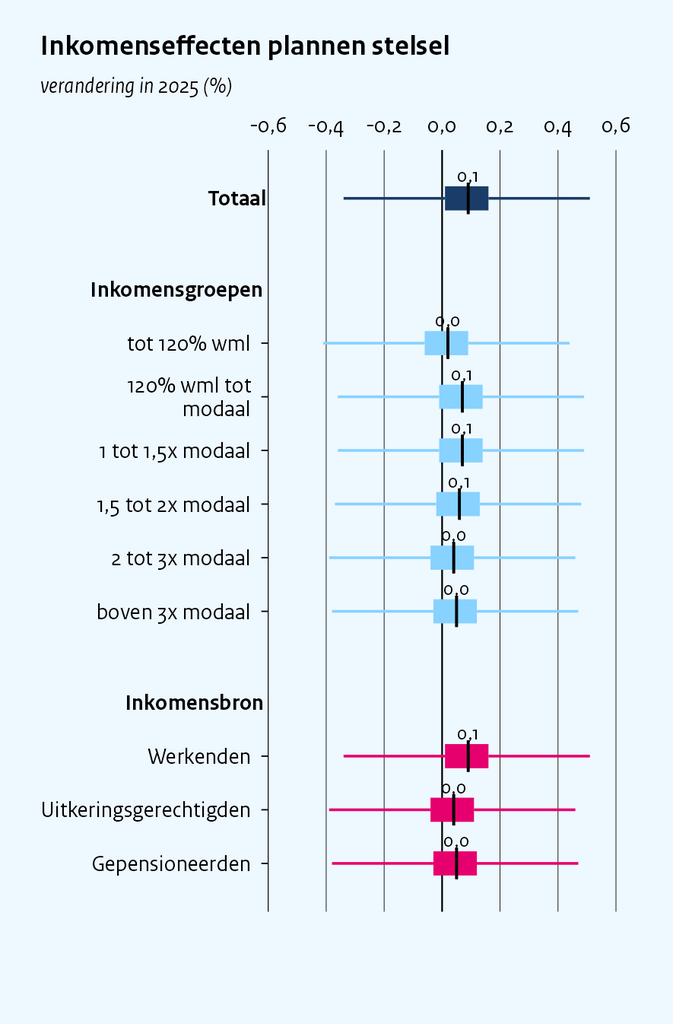

#### Relevant parameters

| plot_type | box |
| --- | --- |
| title | Inkomenseffecten plannen stelsel |
| x | cat |
| p5 | p5 |
| p25 | p25 |
| p50 | p50 |
| p75 | p75 |
| p95 | p95 |
| group | grp |
| box_style | james |
| orientation | horizontal |
| value_axis | top |
| colour_index | 7;5;2 |
| width | 0.45 |
| ylab | verandering in 2025 (%) |
| height | 11.4 |

**How to reproduce this figure:** copy `params.csv`, `generate_plot.bat` and the folder `data` with `box-grouped.csv` to a personal folder. Fill in the parameters above in `params.csv` and start the script. In R you can call `cpb_box()` instead. Follow the example code in section 6.11 to create the plot in R. Alternatively, the csv file can be read with `read.csv()` and used as input to `cpb_box()`.

## 2.4 Grouped boxes in the extended style

The extended boxplot of the introduction takes `group` too. The categories stand under bold group names, as in the grouped boxes above. The figure is saved on the full page width, so a long list of categories fits. This one has 15 categories and is saved with `height = 16`.

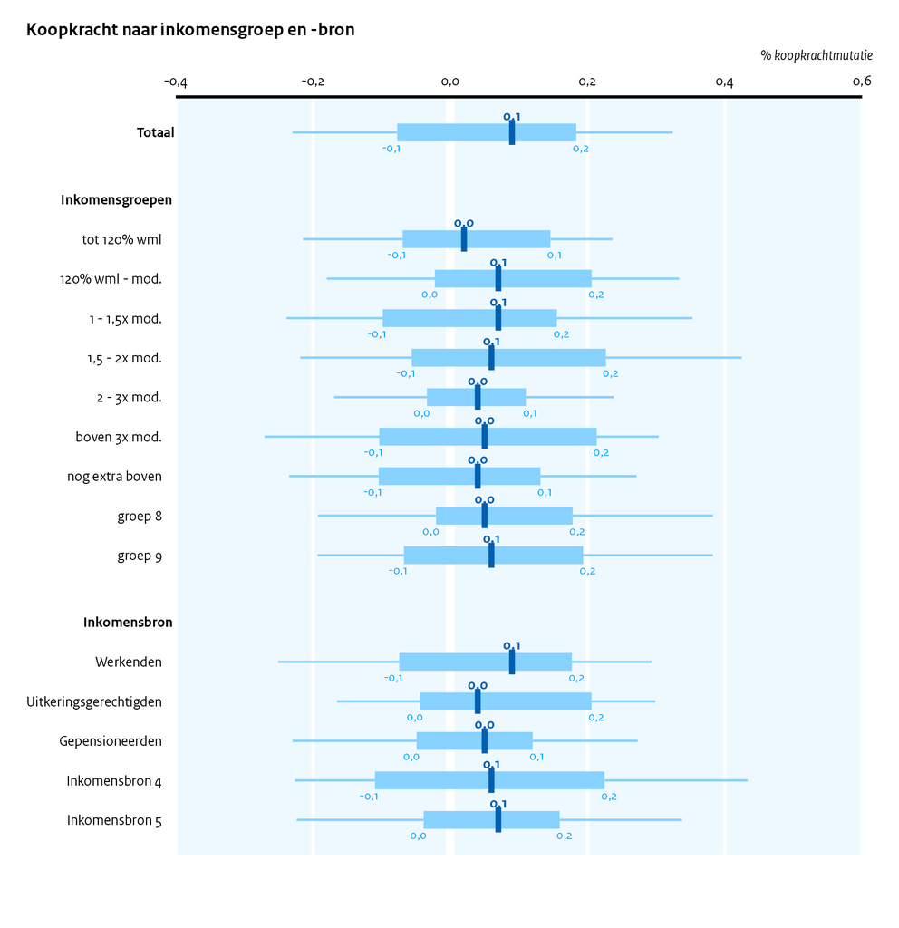

#### Relevant parameters

| plot_type | boxplot_extended |
| --- | --- |
| title | Koopkracht naar inkomensgroep en -bron |
| x | cat |
| group | grp |
| p5 | p5 |
| p25 | p25 |
| p50 | p50 |
| p75 | p75 |
| p95 | p95 |
| ylab | % koopkrachtmutatie |
| page | full |
| height | 16 |

**How to reproduce this figure:** copy `params.csv`, `generate_plot.bat` and the folder `data` with `box-extended-grouped.csv` to a personal folder. Fill in the parameters above in `params.csv` and start the script. In R you can call `cpb_boxplot_extended()` instead. Follow the example code in section 6.12 to create the plot in R. Alternatively, the csv file can be read with `read.csv()` and used as input to `cpb_boxplot_extended()`.

# 3 Colours

The colours of a figure follow from the parameters `colour` or `fill`. This section shows how to choose them.

## 3.1 Default colours

Map a column to `colour` or `fill` and the series get the house colours. The order is the same as in the published figures. It is blue, magenta and taupe, followed by the other colours. A line chart and a column chart of the same series have the same colours. A single series is blue by default. The section One colour shows how to choose another colour.

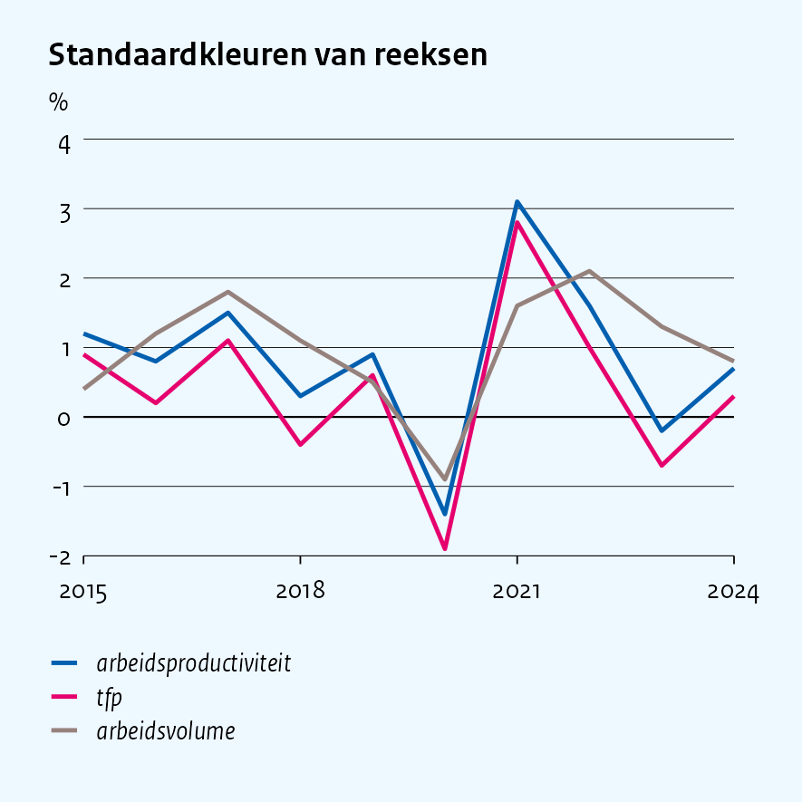

#### Relevant parameters

| plot_type | line |
| --- | --- |
| title | Standaardkleuren van reeksen |
| x | jaar |
| y | waarde |
| colour | reeks |
| ylab | % |

**How to reproduce this figure:** copy `params.csv`, `generate_plot.bat` and the folder `data` with `colour-default.csv` to a personal folder. Fill in the parameters above in `params.csv` and start the script. In R you can call `cpb_line()` instead. Follow the example code in section 6.1 to create the plot in R. Alternatively, the csv file can be read with `read.csv()` and used as input to `cpb_line()`.

## 3.2 Colours by position

The house palette has nine colours. Use `colour_index` to choose them by position. The position of a colour does not change when the default order changes.

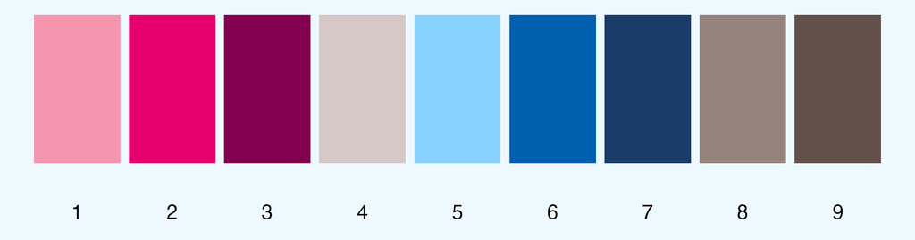

Choose the positions yourself to keep a series on its colour, for example after you reorder the levels. Do the same when you rebuild a published figure.

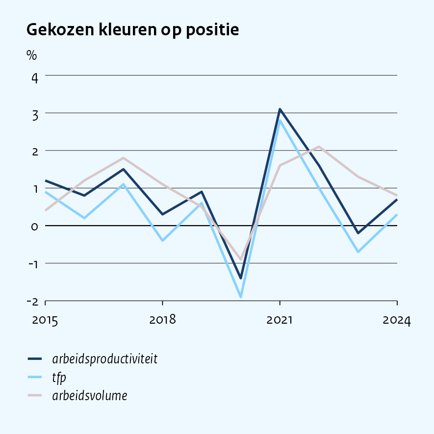

#### Relevant parameters

| plot_type | line |
| --- | --- |
| title | Gekozen kleuren op positie |
| x | jaar |
| y | waarde |
| colour | reeks |
| colour_index | 7;5;4 |
| ylab | % |

**How to reproduce this figure:** copy `params.csv`, `generate_plot.bat` and the folder `data` with `colour-positions.csv` to a personal folder. Fill in the parameters above in `params.csv` and start the script. In R you can call `cpb_line()` instead. Follow the example code in section 6.2 to create the plot in R. Alternatively, the csv file can be read with `read.csv()` and used as input to `cpb_line()`.

## 3.3 Ordered classes

Ordered classes, such as income groups, need a ramp from light to dark. The default colours are meant to be distinct, so they do not show an order. Set `colour_index` to `continuous` for the ramp. The word `discrete` gives the default colours again. The words `qualitative`, `sequential`, `discr` and `blues` name a palette.

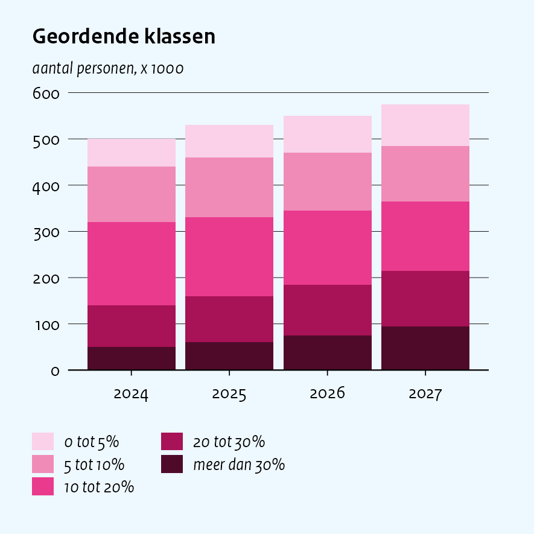

#### Relevant parameters

| plot_type | col |
| --- | --- |
| title | Geordende klassen |
| x | jaar |
| y | n |
| fill | klasse |
| position | stack |
| colour_index | continuous |
| ylab | aantal personen, x 1000 |

**How to reproduce this figure:** copy `params.csv`, `generate_plot.bat` and the folder `data` with `colour-ramp.csv` to a personal folder. Fill in the parameters above in `params.csv` and start the script. In R you can call `cpb_col()` instead. Follow the example code in section 6.3 to create the plot in R. Alternatively, the csv file can be read with `read.csv()` and used as input to `cpb_col()`.

## 3.4 A palette with positions

`colour_index` takes positions or the name of a palette, not both. Use `palette` to choose a palette and `colour_index` to choose the colours in it.

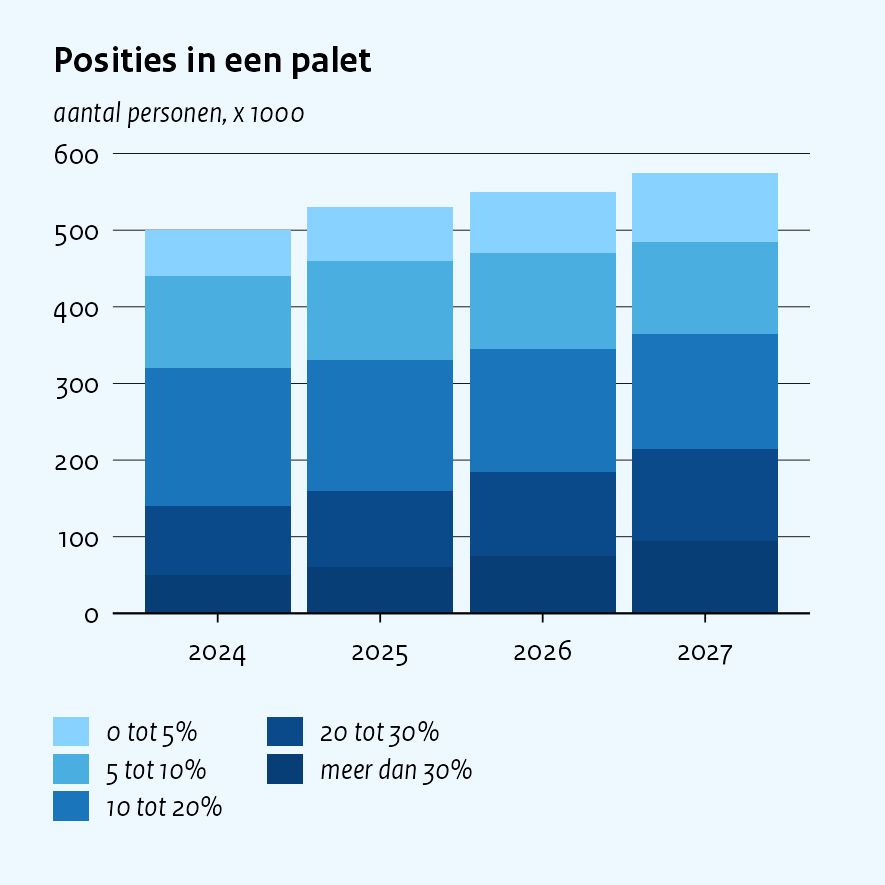

#### Relevant parameters

| plot_type | col |
| --- | --- |
| title | Posities in een palet |
| x | jaar |
| y | n |
| fill | klasse |
| position | stack |
| palette | blues |
| colour_index | 2;3;4;5;6 |
| ylab | aantal personen, x 1000 |

**How to reproduce this figure:** copy `params.csv`, `generate_plot.bat` and the folder `data` with `colour-palette.csv` to a personal folder. Fill in the parameters above in `params.csv` and start the script. In R you can call `cpb_col()` instead. Follow the example code in section 6.4 to create the plot in R. Alternatively, the csv file can be read with `read.csv()` and used as input to `cpb_col()`.

## 3.5 One colour

A single series has one colour. `line_colour` sets it for a line and `fill_colour` for columns. A colour from outside the palette is possible as a hexadecimal code, such as `#820050`. Be sure to use colours that are allowed for the publications.

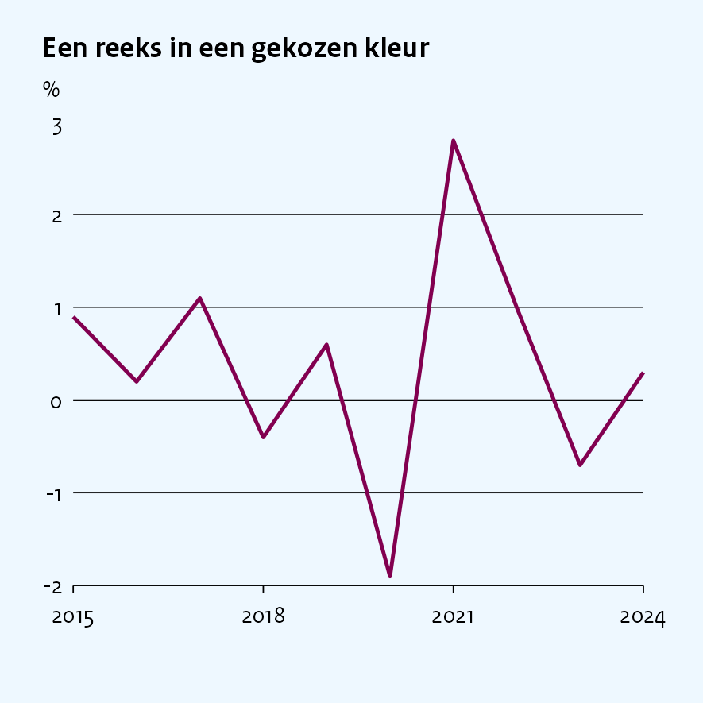

#### Relevant parameters

| plot_type | line |
| --- | --- |
| title | Een reeks in een gekozen kleur |
| x | jaar |
| y | waarde |
| line_colour | #820050 |
| ylab | % |

**How to reproduce this figure:** copy `params.csv`, `generate_plot.bat` and the folder `data` with `colour-single.csv` to a personal folder. Fill in the parameters above in `params.csv` and start the script. In R you can call `cpb_line()` instead. Follow the example code in section 6.5 to create the plot in R. Alternatively, the csv file can be read with `read.csv()` and used as input to `cpb_line()`.

# 4 Maps

The introduction shows a map with classes. This section shows a map with numbers and a map of provinces. All maps use the boundaries that come with the package, so no other packages are needed. A map keeps its real proportions. `save_cpb(preset = "map")` makes it as tall as it needs. The regions are joined by their CBS code, such as `GM0014`, or by their name. A region without a value is not filled and a region that is not found gives a warning.

## 4.1 Numbers on a map

A numeric `value` gets the sequential gradient and a colour bar. The unit goes in `subtitle`. A map has no value axis, so `ylab` does not exist. `reverse` turns the gradient around and `na_fill` fills the regions without a value.

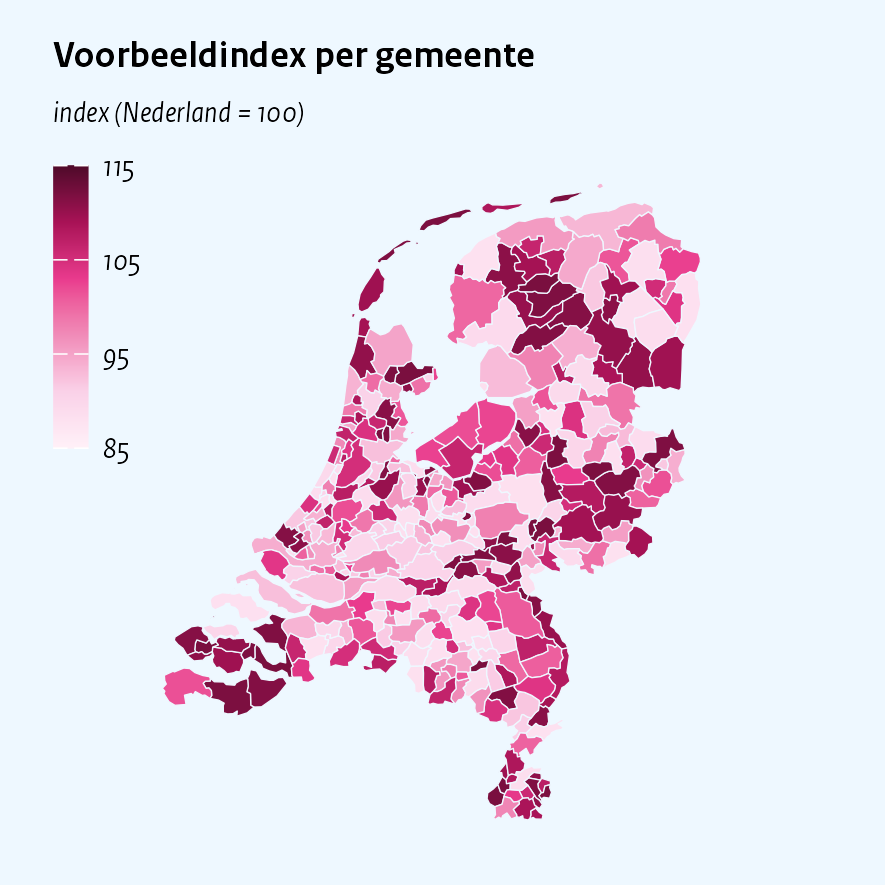

#### Relevant parameters

| plot_type | map |
| --- | --- |
| title | Voorbeeldindex per gemeente |
| region | code |
| value | index |
| subtitle | index (Nederland = 100) |

**How to reproduce this figure:** copy `params.csv`, `generate_plot.bat` and the folder `data` with `map-numbers.csv` to a personal folder. Fill in the parameters above in `params.csv` and start the script. In R you can call `cpb_map()` instead. Follow the example code in section 6.13 to create the plot in R. Alternatively, the csv file can be read with `read.csv()` and used as input to `cpb_map()`.

## 4.2 Provinces

`level = provincie` draws the provinces and `corop` draws the COROP regions. The default level is `gemeente`. A text value gets the house colours. `border_colour` sets the colour of the borders. White gives more contrast on a map with two classes. `legend = bottom` puts the legend below the map and `none` removes it. A region without a value, here Utrecht, is not filled. Set `na_fill` to fill it with a colour or a position in the house colours. An item called “Geen gegevens” is then added to the legend, or “No data” when `style` is english. A title wider than the map gives a warning of `save_cpb()`. Break it with `\n`, as is done here.

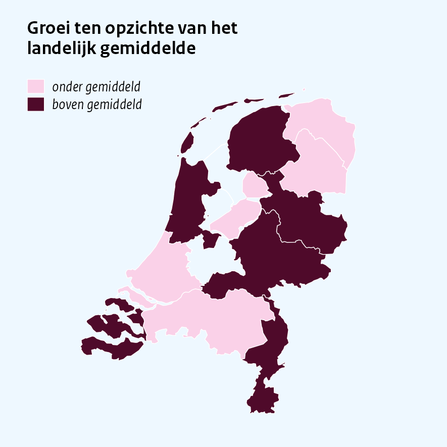

#### Relevant parameters

| plot_type | map |
| --- | --- |
| title | Groei ten opzichte van het\nlandelijk gemiddelde |
| region | naam |
| value | klasse |
| level | provincie |
| colour_index | 2;6 |
| border_colour | white |

**How to reproduce this figure:** copy `params.csv`, `generate_plot.bat` and the folder `data` with `map-provinces.csv` to a personal folder. Fill in the parameters above in `params.csv` and start the script. In R you can call `cpb_map()` instead. Follow the example code in section 6.14 to create the plot in R. Alternatively, the csv file can be read with `read.csv()` and used as input to `cpb_map()`.

# 5 More possibilities in R

The figures in this section need R. Every function returns a ggplot2 object, so you can add layers and scales with `+`. See also the section on ggplot2 in the introduction.

## 5.1 A line over stacked columns

A decomposition has stacked columns and the total as a line. This is `cpb_col()` plus a `geom_line()`.

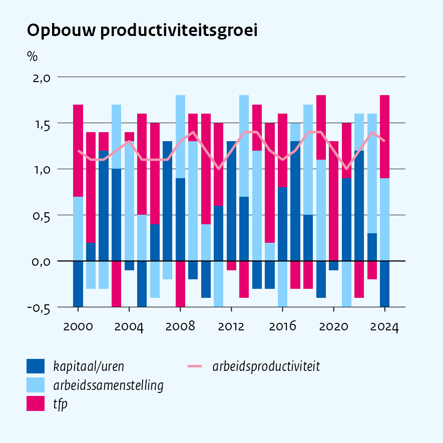

```r
componenten <- c("kapitaal/uren", "arbeidssamenstelling", "tfp")
dec <- expand_grid(
  jaar = 2000:2024,
  # reversed levels stack the first component nearest to zero
  component = factor(componenten, levels = rev(componenten))
) |>
  mutate(bijdrage = round(0.4 + 0.9 * sin(jaar * 1.3 +
                                            as.numeric(component) * 2), 1))
totaal <- dec |>
  summarise(bijdrage = sum(bijdrage), .by = jaar)

cpb_col(dec, x = jaar, y = bijdrage, fill = component,
        position = "stack", colour_index = c(2, 5, 6), width = 0.75,
        title = "Opbouw productiviteitsgroei", ylab = "%") +
  geom_line(
    data = totaal,
    mapping = aes(x = jaar, y = bijdrage, colour = "arbeidsproductiviteit"),
    linewidth = 0.55, inherit.aes = FALSE
  ) +
  scale_colour_cpb_manual(index = 1) +
  labs(colour = NULL) +
  guides(fill = guide_legend(reverse = TRUE, order = 1),
         colour = guide_legend(order = 2)) +
  theme(legend.box = "horizontal", legend.box.just = "top")
```

## 5.2 Boxes with a fill per year

Map `fill` and pass a `position_dodge()` for two boxes per category. This works with the default style `ggcpb` only.

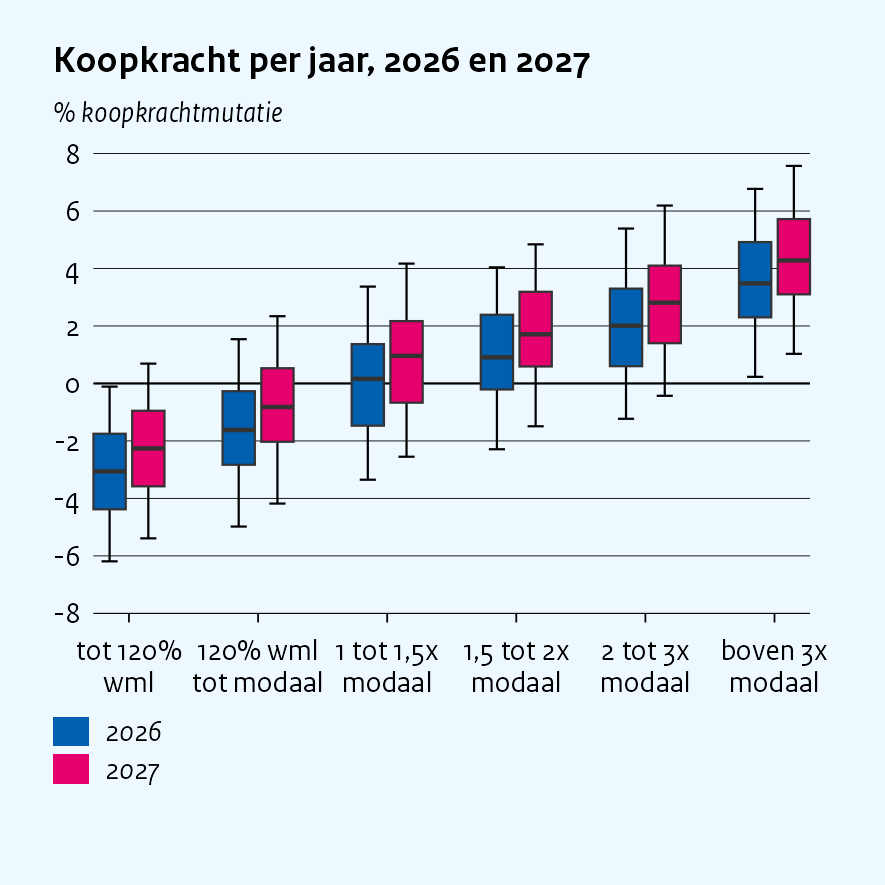

```r
kk2 <- expand_grid(kk, jaar = factor(c(2026, 2027))) |>
  mutate(across(p5:p95, \(q) q + (jaar == "2027") * 0.8),
         groep = factor(groep, levels = rev(groepen),
                        labels = c("tot 120%\nwml", "120% wml\ntot modaal",
                                   "1 tot 1,5x\nmodaal", "1,5 tot 2x\nmodaal",
                                   "2 tot 3x\nmodaal", "boven 3x\nmodaal")))

cpb_box(kk2, x = groep,
        p5 = p5, p25 = p25, p50 = p50, p75 = p75, p95 = p95,
        fill = jaar, position = position_dodge(width = 0.6),
        colour_index = c(6, 2),
        title = "Koopkracht per jaar, 2026 en 2027",
        ylab = "% koopkrachtmutatie")
```

## 5.3 Adding a forecast window manually

The parameter `forecast_x` draws the forecast window for you, as shown in the introduction. You can also draw it yourself with `annotate()`. A white rectangle covers the forecast years, a dashed line marks the start and a text names the window. The new `scale_x_continuous()` replaces the one of the function, and ggplot2 tells you so in a message.

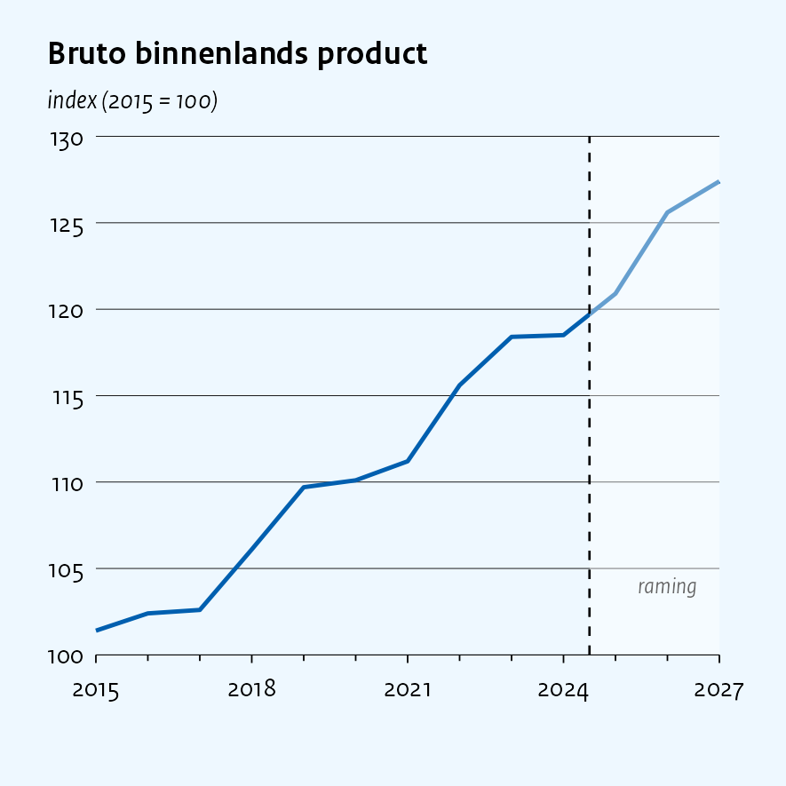

```r
bbp <- tibble(jaar  = 2015:2027,
              index = round(100 * 1.02^(jaar - 2015) +
                              1.5 * sin(jaar * 1.7), 1))

cpb_line(bbp, x = jaar, y = index,
         title = "Bruto binnenlands product",
         ylab  = "index (2015 = 100)") +
  annotate("rect", xmin = 2024.5, xmax = Inf, ymin = -Inf, ymax = Inf,
           fill = "white", alpha = 0.4) +
  annotate("text", x = 2026, y = 104, label = "raming",
           size = 2.2, colour = "#666666",
           family = cpb_font_family(), fontface = "italic") +
  geom_vline(xintercept = 2024.5, linetype = "dashed", linewidth = 0.3) +
  scale_x_continuous(breaks = seq(2015, 2027, 3), minor_breaks = 2015:2027,
                     guide = guide_axis(minor.ticks = TRUE))
```

## 5.4 Export

`save_cpb()` writes a figure at the page width. It is 7.5 cm for `half`, 15.5 cm for `full` and 6.8 cm for `small`. The height is the report height, unless you set `height`. Use `preset = "map"` for a map and `dpi` for the resolution. Text sizes are absolute, so the size of the canvas is part of the design. Draw at the page width and scale only the display.

```r
p <- cpb_col(auto, x = inkomensgroep, y = share, orientation = "horizontal")
save_cpb("koopkracht.png", p, page = "half")
save_cpb("koopkracht_breed.png", p, page = "full", height = 8 / 2.54)
```

# 6 Example code to create figures in R

The code below creates the figures above in R. It first builds the data, then draws the figure. It is the same code that made the figures in this document. Start the script with these lines.

```r
library(conflicted)
library(ggcpb)
library(ggplot2)
library(dplyr)
library(tidyr)

options(ggcpb.style = "dutch") # style of the whole publication
```

## 6.1 Default colours

```r
reeksen <- c("arbeidsproductiviteit", "tfp", "arbeidsvolume")
groei <- tibble(
  reeks = factor(rep(reeksen, each = 10), levels = reeksen),
  jaar  = rep(2015:2024, 3),
  waarde = c(1.2, 0.8, 1.5, 0.3, 0.9, -1.4, 3.1, 1.6, -0.2, 0.7,
             0.9, 0.2, 1.1, -0.4, 0.6, -1.9, 2.8, 1.0, -0.7, 0.3,
             0.4, 1.2, 1.8, 1.1, 0.5, -0.9, 1.6, 2.1, 1.3, 0.8)
)
cpb_line(groei, x = jaar, y = waarde, colour = reeks,
         title = "Standaardkleuren van reeksen", ylab = "%")
```

## 6.2 Colours by position

```r
reeksen <- c("arbeidsproductiviteit", "tfp", "arbeidsvolume")
groei <- tibble(
  reeks = factor(rep(reeksen, each = 10), levels = reeksen),
  jaar  = rep(2015:2024, 3),
  waarde = c(1.2, 0.8, 1.5, 0.3, 0.9, -1.4, 3.1, 1.6, -0.2, 0.7,
             0.9, 0.2, 1.1, -0.4, 0.6, -1.9, 2.8, 1.0, -0.7, 0.3,
             0.4, 1.2, 1.8, 1.1, 0.5, -0.9, 1.6, 2.1, 1.3, 0.8)
)
cpb_line(groei, x = jaar, y = waarde, colour = reeks,
         colour_index = c(7, 5, 4),
         title = "Gekozen kleuren op positie", ylab = "%")
```

## 6.3 Ordered classes

```r
klassen <- c("0 tot 5%", "5 tot 10%", "10 tot 20%", "20 tot 30%",
             "meer dan 30%")
intensiteit <- tibble(
  jaar   = rep(2024:2027, each = 5),
  klasse = factor(rep(klassen, 4), levels = klassen),
  n      = c(60, 120, 180, 90, 50, 70, 130, 170, 100, 60,
             80, 125, 160, 110, 75, 90, 120, 150, 120, 95)
)
cpb_col(intensiteit, x = jaar, y = n, fill = klasse,
        position = "stack",
        colour_index = "continuous",
        title = "Geordende klassen", ylab = "aantal personen, x 1000")
```

## 6.4 A palette with positions

```r
klassen <- c("0 tot 5%", "5 tot 10%", "10 tot 20%", "20 tot 30%",
             "meer dan 30%")
intensiteit <- tibble(
  jaar   = rep(2024:2027, each = 5),
  klasse = factor(rep(klassen, 4), levels = klassen),
  n      = c(60, 120, 180, 90, 50, 70, 130, 170, 100, 60,
             80, 125, 160, 110, 75, 90, 120, 150, 120, 95)
)
cpb_col(intensiteit, x = jaar, y = n, fill = klasse,
        position = "stack",
        palette = "blues", colour_index = c(2, 3, 4, 5, 6),
        title = "Posities in een palet", ylab = "aantal personen, x 1000")
```

## 6.5 One colour

```r
reeksen <- c("arbeidsproductiviteit", "tfp", "arbeidsvolume")
groei <- tibble(
  reeks = factor(rep(reeksen, each = 10), levels = reeksen),
  jaar  = rep(2015:2024, 3),
  waarde = c(1.2, 0.8, 1.5, 0.3, 0.9, -1.4, 3.1, 1.6, -0.2, 0.7,
             0.9, 0.2, 1.1, -0.4, 0.6, -1.9, 2.8, 1.0, -0.7, 0.3,
             0.4, 1.2, 1.8, 1.1, 0.5, -0.9, 1.6, 2.1, 1.3, 0.8)
)
tfp <- dplyr::filter(groei, reeks == "tfp")
cpb_line(tfp, x = jaar, y = waarde, line_colour = cpb_cols(3),
         title = "Een reeks in een gekozen kleur", ylab = "%")
```

## 6.6 Stacked columns

```r
sectoren <- c("industrie", "diensten", "landbouw", "overheid")
tw <- tibble(
  jaar   = rep(2023:2027, each = 4),
  sector = factor(rep(sectoren, 5), levels = sectoren),
  waarde = c(18.2, 11.5, 24.1, 7.6, 17.4, 12.9, 22.8, 8.1, 19.6, 13.4, 21.5,
             8.8, 20.1, 12.2, 23.3, 9.4, 21.3, 14.0, 22.1, 10.2)
)
cpb_col(tw, x = jaar, y = waarde, fill = sector,
        position = "stack",
        title = "Toegevoegde waarde per sector", ylab = "mld euro")
```

## 6.7 Dodged columns

```r
regios <- c("Noord", "Oost", "Zuid", "West")
scenarios <- c("basispad", "beleidsvariant")
scenario <- tibble(
  regio    = factor(rep(regios, each = 2), levels = regios),
  scenario = factor(rep(scenarios, 4), levels = scenarios),
  effect   = c(2.4, 3.1, -0.8, 1.2, 4.6, 5.2, 1.9, 3.3)
)
cpb_col(scenario, x = regio, y = effect, fill = scenario,
        title = "Effect per regio en scenario", ylab = "% mutatie")
```

## 6.8 Limits and percentages

```r
groepen <- c("boven 3x modaal", "2 tot 3x modaal", "1,5 tot 2x modaal",
             "1 tot 1,5x modaal", "120% wml tot modaal", "tot 120% wml")
auto <- tibble(
  inkomensgroep = factor(groepen, levels = groepen),
  share         = c(13, 14, 19, 26, 35, 62)
)
cpb_col(auto, x = inkomensgroep, y = share,
        orientation = "horizontal", pct_axis = TRUE,
        value_limits = c(0, 100), width = 0.6,
        title = "Huishoudens zonder auto", ylab = "inkomensgroep",
        xlab = "aandeel huishoudens")
```

## 6.9 James style

```r
groepen <- c("boven 3x modaal", "2 tot 3x modaal", "1,5 tot 2x modaal",
             "1 tot 1,5x modaal", "120% wml tot modaal", "tot 120% wml")
kk <- tibble(
  groep = factor(groepen, levels = groepen),
  p5  = c(0.23, -1.23, -2.29, -3.35, -4.98, -6.19),
  p25 = c(2.30, 0.60, -0.21, -1.47, -2.83, -4.38),
  p50 = c(3.48, 2.01, 0.91, 0.16, -1.62, -3.06),
  p75 = c(4.92, 3.30, 2.39, 1.37, -0.27, -1.75),
  p95 = c(6.77, 5.39, 4.04, 3.37, 1.54, -0.11)
)
cpb_box(kk, x = groep,
        p5 = p5, p25 = p25, p50 = p50, p75 = p75, p95 = p95,
        box_style = "james", orientation = "horizontal",
        title = "Koopkracht per inkomensgroep", subtitle = "inkomensgroep",
        ylab = "% koopkrachtmutatie")
```

## 6.10 Modern style

```r
groepen <- c("boven 3x modaal", "2 tot 3x modaal", "1,5 tot 2x modaal",
             "1 tot 1,5x modaal", "120% wml tot modaal", "tot 120% wml")
kk <- tibble(
  groep = factor(groepen, levels = groepen),
  p5  = c(0.23, -1.23, -2.29, -3.35, -4.98, -6.19),
  p25 = c(2.30, 0.60, -0.21, -1.47, -2.83, -4.38),
  p50 = c(3.48, 2.01, 0.91, 0.16, -1.62, -3.06),
  p75 = c(4.92, 3.30, 2.39, 1.37, -0.27, -1.75),
  p95 = c(6.77, 5.39, 4.04, 3.37, 1.54, -0.11)
)
cpb_box(kk, x = groep,
        p5 = p5, p25 = p25, p50 = p50, p75 = p75, p95 = p95,
        box_style = "modern", orientation = "horizontal", width = 0.35,
        value_accuracy = 0.1,
        title = "Koopkracht per inkomensgroep", subtitle = "inkomensgroep",
        ylab = "% koopkrachtmutatie")
```

## 6.11 Grouped boxes

```r
inkomen <- c("tot 120% wml", "120% wml tot modaal", "1 tot 1,5x modaal",
             "1,5 tot 2x modaal", "2 tot 3x modaal", "boven 3x modaal")
bron <- c("Werkenden", "Uitkeringsgerechtigden", "Gepensioneerden")
categorieen <- c("Totaal", inkomen, bron)
ink <- tibble(
  cat = factor(categorieen, levels = categorieen),
  grp = factor(rep(c("Totaal", "Inkomensgroepen", "Inkomensbron"),
                   c(1, 6, 3)),
               levels = c("Totaal", "Inkomensgroepen", "Inkomensbron")),
  p50 = c(0.09, 0.02, 0.07, 0.07, 0.06, 0.04, 0.05, 0.09, 0.04, 0.05)
) |>
  mutate(p25 = p50 - 0.08, p75 = p50 + 0.07,
         p5 = p25 - 0.35, p95 = p75 + 0.35)
cpb_box(ink, x = cat, p5 = p5, p25 = p25, p50 = p50, p75 = p75, p95 = p95,
        group = grp, box_style = "james", orientation = "horizontal",
        value_axis = "top",
        colour_index = c(7, 5, 2),
        width = 0.45, title = "Inkomenseffecten plannen stelsel",
        ylab = "verandering in 2025 (%)")
```

## 6.12 Grouped boxes in the extended style

```r
groepen2 <- c("tot 120% wml", "120% wml - mod.", "1 - 1,5x mod.",
              "1,5 - 2x mod.", "2 - 3x mod.", "boven 3x mod.",
              "nog extra boven", "groep 8", "groep 9")
categorieen2 <- c("Totaal", groepen2, "Werkenden", "Uitkeringsgerechtigden",
                  "Gepensioneerden", "Inkomensbron 4", "Inkomensbron 5")
ink2 <- tibble(
  cat = factor(categorieen2, levels = categorieen2),
  grp = factor(rep(c("Totaal", "Inkomensgroepen", "Inkomensbron"),
                   c(1, 9, 5)),
               levels = c("Totaal", "Inkomensgroepen", "Inkomensbron")),
  p50 = c(0.09, 0.02, 0.07, 0.07, 0.06, 0.04, 0.05, 0.04, 0.05, 0.06,
          0.09, 0.04, 0.05, 0.06, 0.07)
) |>
  mutate(p25 = p50 - 0.12 - 0.05 * sin(seq_along(p50) * 1.9),
         p75 = p50 + 0.12 + 0.05 * sin(seq_along(p50) * 2.7 + 1),
         p5  = p25 - 0.15 - 0.06 * sin(seq_along(p50) * 3.1),
         p95 = p75 + 0.15 + 0.06 * sin(seq_along(p50) * 1.3 + 2))
cpb_boxplot_extended(ink2, x = cat, group = grp,
                     p5 = p5, p25 = p25, p50 = p50, p75 = p75, p95 = p95,
                     title = "Koopkracht naar inkomensgroep en -bron",
                     ylab = "% koopkrachtmutatie")
```

## 6.13 Numbers on a map

```r
codes <- unique(cpb_nl_geo("gemeente")$code)
gemeenten_ct <- tibble(
  code  = codes,
  index = round(100 + 12 * sin(seq_along(codes) / 9), 1)
)
cpb_map(gemeenten_ct, region = code, value = index,
        title = "Voorbeeldindex per gemeente",
        subtitle = "index (Nederland = 100)")
```

## 6.14 Provinces

```r
namen <- unique(cpb_nl_geo("provincie")$name)
provincies <- tibble(
  naam   = namen,
  klasse = factor(rep(c("onder gemiddeld", "boven gemiddeld"), 6),
                  levels = c("onder gemiddeld", "boven gemiddeld"))
) |>
  dplyr::filter(naam != "Utrecht")
cpb_map(provincies, region = naam, value = klasse, level = "provincie",
        colour_index = c(2, 6), border_colour = "white",
        title = "Groei ten opzichte van het\nlandelijk gemiddelde")
```

All data in this document is made up. It is generated to show the figures and is not real data.